# Supplementary Material

Niklas Hausmann

02/07/2020

# Introduction

In this file, we describe the process of creating the figures included in the supplementary Material of the paper. These figures are:

1. **Aperture sizes** for all sites by bulk sample and for the entire site
2. **Aperture sizes** by bulk sample compared to changes in **Richness**, **Simpson Index**, and **Percentage of *C. fasciatus***
3. **Species composition** by weight percentage and ranks on site-level.

```r
library(here)
library(tidyverse)
Aps <- read.csv(here("data/Apertures.csv"))
Species <- read.csv(here("data/Species.csv"))

source(here("code/R_rainclouds.R"))
source(here("code/summarySE.R"))
library(patchwork)
library(viridis)
library(ggrepel)
library(cowplot)
```

# 1. Aperture sizes

First, we want to look at the changing mean aperture size throughout the column, for which we will need to calculate the average size per sample.

```r
ApsMeans <-  summarySE(na.omit(Aps),
            measurevar = "Aperture",
            groupvars = c("Site", "Sample")) %>%
  select(-N, -se, -ci)

head(ApsMeans)
```

```
##     Site Sample Aperture_mean Aperture_median        sd
## 1 JE0003    527      20.08900           19.95 0.9880784
## 2 JE0004    529      19.17273           19.11 1.0507952
## 3 JE0004    676      18.69920           18.63 1.0175143
## 4 JE0004    678      18.87647           18.88 1.1835114
## 5 JE0004    684      18.70222           18.76 1.2148342
## 6 JE0004    686      18.98349           18.80 1.3119662
```

Now that the mean data is available we cnan plot it on top of the individual points. To do this automatically for all sites, we can use a for-loop that repeats as often as the number of sites and that each time accesses the bulk sample data together with each samples mean value, which we use to draw a line from one sample to another (`PLOT1`). In `PLOT2` we look at the same data, but group them by `Site`. Using the `patchwork` package, we simply add them together, before saving them.

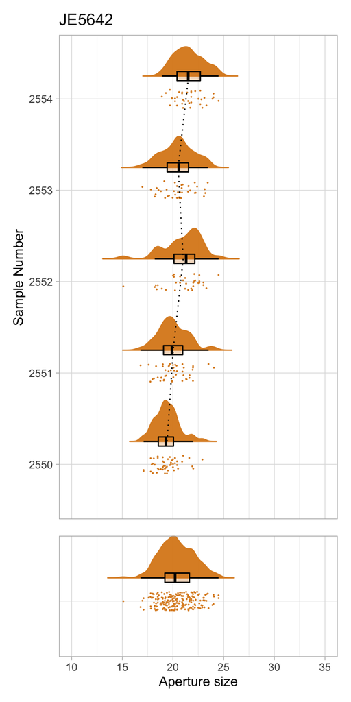

```r
 for (i in 1:length(levels(Species$Site))) {
PLOT1<-    Aps %>%
  filter(Site==levels(Species$Site)[i]) %>%
  ggplot(
    aes(
      x = as.character(Sample),
      y = Aperture,
      fill=Site,
      col=Site
    )) +
      geom_flat_violin(
        position = position_nudge(x = +0.25, y = 0),
        adjust = 0.75,
        trim = FALSE,
        alpha = .99
      ) +
      geom_point(position = position_jitter(width = .1),
                 size = 0.05
      ) +
      geom_boxplot(
        position = position_nudge(x = +0.25, y = 0),
        aes(x = as.character(Sample), y = Aperture),
        outlier.shape = NA,
        alpha = 0.3,
        width = .1,
        colour = "BLACK"
      ) +
      ylab('Aperture size') + xlab('Sample Number') + coord_flip() + guides(fill = FALSE, colour = FALSE) +  ylim(10, 35)+
      geom_line(
        data = ApsMeans[ApsMeans$Site==levels(Species$Site)[i],],
        position = position_nudge(x = +0.25, y = 0),
        aes(x = as.character(Sample), y = Aperture_mean, group=Site),
        #inherit.aes = FALSE,
        linetype = 3, col="Black"
      ) +
      scale_color_manual(values="#DD8D29")+ scale_fill_manual(values="#DD8D29")+
      theme(axis.title.x  = element_blank()) +theme_light()+
      theme(axis.title.x=element_blank(),axis.text.x=element_blank(),axis.ticks.x=element_blank())+
      ggtitle(levels(Species$Site)[i])


  PLOT2 <- Aps %>%
    filter(Site==levels(Species$Site)[i]) %>%
    ggplot(
      aes(
    x = Site,
    y = Aperture,
    fill = Site,
    colour = Site
  )) +
    geom_flat_violin(
      position = position_nudge(x = +0.25, y = 0),
      adjust = 0.75,
      trim = FALSE,
      alpha = .99
    ) +
    geom_point(position = position_jitter(width = .1),
               size = 0.05
    ) +
    geom_boxplot(
      position = position_nudge(x = +0.25, y = 0),
      aes(x = Site, y = Aperture),
      outlier.shape = NA,
      alpha = 0.3,
      width = .1,
      colour = "BLACK"
    ) +
    ylab('Aperture size') + coord_flip() + guides(fill = FALSE, colour = FALSE) +   ylim(10, 35)+
    scale_color_manual(values="#DD8D29")+ scale_fill_manual(values="#DD8D29")+
    theme_light()+theme(axis.title.y=element_blank(),axis.text.y=element_blank(),axis.ticks.y=element_blank())

PLOT1/PLOT2+plot_layout(ncol = 1, heights = c(0.8, 0.2))

ggsave(here(paste0("/Figures and supplementary material/Supplementary Material/1. Aperture Sizes/Aperture_Plot_",levels(Species$Site)[i],".pdf")),height = 10, width = 5)

}
```

# 2. Aperture sizes compared to species composition and diversity indices

To compare changes in aperture with changes in species composition and especially the abundance of *C. fasciatus*, we need to add a bit more information on the site composition. First, we will need a dataframe containing the species weight (`Species`) and aggregate it to `sample` level.

```r
Species$Weight[Species$Weight == 0.5] <- 0.25 #Again we adjust for weight


Species <- Species %>% #and spread the table into a wider format
  group_by(Site, Sample, Speciesname) %>%
  summarise(Weight = sum(Weight)) %>%
  spread(Speciesname, Weight, fill = 0)
Species <- aggregate(Species[, 3:97], by = list(Site = Species$Site,Sample = Species$Sample), FUN = sum)# This time we aggregate by sample rather than Site
```

We will use these weights to calculate several diversity indices: the [Simpson Index](https://en.wikipedia.org/wiki/Simpson_Index) using the `vegan` package as well as the [Richness](https://en.wikipedia.org/wiki/Species_richness) of each sample by counting the number of species that occur, and the [Shannon index](https://en.wikipedia.org/wiki/Diversity_index#Shannon_index).

```r
library(vegan)
#Diversity Indeces
Diversity <- Species[,1:2]
#Simpson Index
Diversity$Simpson <- diversity(Species[,3:97],index="simpson")
#Shannon Index
Diversity$Shannon <- diversity(Species[,3:97],index="shannon")


#Species Richness
Diversity$Richness <- rowSums(Species[,3:97] > 0)
```

Lastly we want to compare this to the changes in abundance of *C. fasciatus*, which we can simply extract as percentage from the `Species` layer, by dividing its own weight by the total weight of shells within each sample

```r
#Conomurex fasciatus Percentage
CFP <- Species %>%
              mutate("CFP" = round(100 * `Conomurex fasciatus` / rowSums(Species[, 3:97]),2)) %>%
              select(CFP)

Diversity <- Diversity %>%
                      cbind(CFP)
```

To make the figure, we need to combine 5 graphs via `patchwork.` The first graph is similar to the ones in the first chapter. The others are simple line plots in `ggplot`. We will again use a `for loop` for this, which repeats as often as there are sites with changes in aperture size throughout the column.

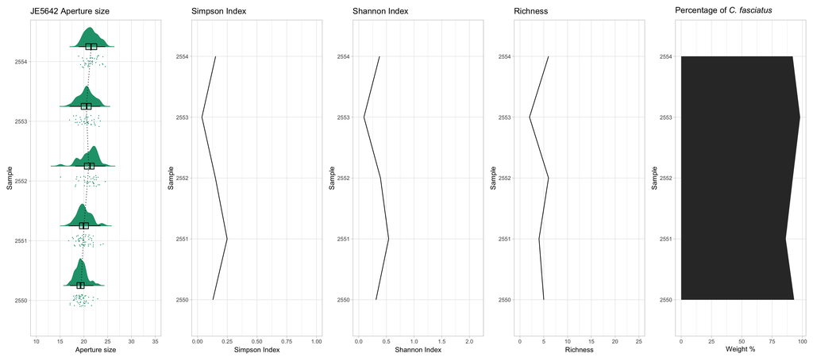

```r
library(patchwork)
for (i in 1:length(levels(Aps$Site))) {
      # if (length(Apertures[[i]]) < 2) {#remove trivial sites with only 1 sample
      if(length(Aps[Aps$Site==levels(Aps$Site)[i],])<2) {#remove trivial sites with only 1 sample
        next
      }

#Aperture Size graph by layer
PLOT1<- Aps %>%
             filter(Site==levels(Aps$Site)[i]) %>%
        ggplot(
          aes(
        x = as.character(Sample),
        y = Aperture,
        fill = Site,
        colour = Site
      )) +
        geom_flat_violin(
          position = position_nudge(x = +0.25, y = 0),
          adjust = 0.75,
          trim = FALSE,
          alpha = .99
        ) +
        geom_point(position = position_jitter(width = .1),
                   size = 0.05
        ) +
        geom_boxplot(
          position = position_nudge(x = +0.25, y = 0),
          aes(x = as.character(Sample), y = Aperture),
          outlier.shape = NA,
          alpha = 0.3,
          width = .1,
          colour = "BLACK"
        ) +
        ylab('Aperture size') + xlab('Sample') + coord_flip() + guides(fill = FALSE, colour = FALSE) +  ylim(10, 35)+
        geom_line(
          data = ApsMeans[ApsMeans$Site==levels(Aps$Site)[i],],
          position = position_nudge(x = +0.25, y = 0),
          aes(x = as.character(Sample), y = Aperture_mean, group = Site),
          inherit.aes = FALSE,
          linetype = 3
        ) +
        scale_colour_brewer(palette = "Dark2") +
        scale_fill_brewer(palette = "Dark2") +theme(axis.title.x  = element_blank()) +theme_light()+
        ggtitle(paste0(levels(Aps$Site)[i]," Aperture size"))


# Graphs for Diversity Indeces

## Simpson index
PLOT2 <-
  Diversity %>%
  filter(Site == levels(Aps$Site)[i]) %>%
  ggplot(aes(x = as.character(Sample), y = Simpson)) +
  coord_flip() + guides(fill = FALSE, colour = FALSE) +
  geom_line(
    aes(
      x = as.character(Sample),
      y = Simpson,
      group = 1
    ),
    inherit.aes = FALSE,
    linetype = 1
  ) + ylim(0, 1) + ylab('Simpson Index') +
  scale_colour_brewer(palette = "Dark2") +
  scale_fill_brewer(palette = "Dark2") + theme(axis.title.x  = element_blank()) +
  theme_light() + xlab("Sample")+
  ggtitle("Simpson Index")

 ## Shannon index

PLOT3 <-
  Diversity %>%
    filter(Site == levels(Aps$Site)[i]) %>%
    ggplot(aes(x = as.character(Sample), y = Shannon)) +
    coord_flip() + guides(fill = FALSE, colour = FALSE) +
    geom_line(
      aes(
        x = as.character(Sample),
        y = Shannon,
        group = 1
      ),
      inherit.aes = FALSE,
      linetype = 1
    ) + ylim(0, 2.15) + ylab('Shannon Index') +
    scale_colour_brewer(palette = "Dark2") +
    scale_fill_brewer(palette = "Dark2") + theme(axis.title.x  = element_blank()) +
    theme_light() + xlab("Sample")+
  ggtitle("Shannon Index")



#Graph for Richness
PLOT4 <- Diversity %>%
  filter(Site == levels(Aps$Site)[i]) %>%
  ggplot(
    aes(
    x = as.character(Sample),
    y = Richness
  ))+ ylim(0,25)+
    ylab('Richness') + xlab('Sample') + coord_flip() +
    geom_line(aes(x = as.character(Sample), y = Richness, group = Site),
              inherit.aes = FALSE,
              linetype = 1
    ) +
    scale_colour_brewer(palette = "Dark2") + xlab("Sample")+
    scale_fill_brewer(palette = "Dark2") +theme(axis.title.x  = element_blank()) +theme_light()+
    ggtitle("Richness")


#PLOT 5 to draw percentage of C. fasciatus
PLOT5 <-  Diversity %>%
    filter(Site == levels(Aps$Site)[i]) %>%
    ggplot(
      aes(
    x = as.character(Sample),
    y = CFP,fill=Site
  ))+
    ylab(expression('Weight %')) + xlab('Sample') + coord_flip() +
    geom_area(aes(x = as.character(Sample), y = CFP, group = Site),
              inherit.aes = FALSE,
              linetype = 1 ) +
    scale_colour_brewer(palette = "Dark2") + xlab("Sample")+
    scale_fill_brewer(palette = "Dark2") +theme(axis.title.x  = element_blank()) +theme_light()+
    ggtitle(expression('Percentage of'~ italic("C. fasciatus")))


PLOT1+PLOT2+PLOT3+PLOT4+PLOT5+plot_layout(ncol = 5)

ggsave(here(paste0("/Figures and supplementary material/Supplementary Material/2. Site-based Diversity/Diversity_Indeces_in_",levels(Aps$Site)[i],".pdf")),height= 8, width = 18)

}
```

# 3. Species ranks by site

Before we start working on the figures we require the dataset for the weight’s individual ranking of each species within each site (`Ranks`). Before we do that, we need to aggregate the weight data from sample level to site level.

```r
#Aggregate SW to site level
Species <- aggregate(Species[, 3:97], by = list(Site = Species$Site,Sample = Species$Sample), FUN = sum)# This time we aggregate by sample rather than Site


Species <- Species %>%
  separate(Site, sep = 6, into = "Site") %>%
  group_by(Site) %>%
  summarise_each(funs(sum))
```

Now that we have the data structured by site, we can calculate the ranks.

```r
SpeciesRound <- column_to_rownames(Species,var="Site")

SpeciesRound <- round(SpeciesRound[,2:96])#this step rounds the data and also drops the sample information in the first column of Species

source(here('code/rankabundance.R'))

Ranks <- data.frame() #main dataframe
Rank <- data.frame() #single site dataframe used temporarily for each row's loop

for (i in 1:length(SpeciesRound[,1])) {

  Rank<- rankabundance(SpeciesRound[i,])#make ranking of species abundance. This step will produce a lof of NaNs but that is ok
  Rank <- subset(Rank, Rank[,2] != 0, select=c(rank, abundance, proportion, logabun)) #remove unneccesary colums and rows with species = 0
  Rank <- data.frame(Rank,Site=rep(rownames(SpeciesRound[i,]),c(length(Rank[,1]))), SpeciesRound=rownames(Rank))

  Ranks <- rbind(Ranks,Rank)
}

rm(Rank,i)#no need for this after the loop is finished
```

Lastly, we determine whether a species is dominant at the site or not using the arbitrary cutoff of 2% by weight

```r
Ranks <- Ranks %>%
          mutate(Dominant=ifelse(Ranks$proportion <2, "Marginal","Dominant"))
```

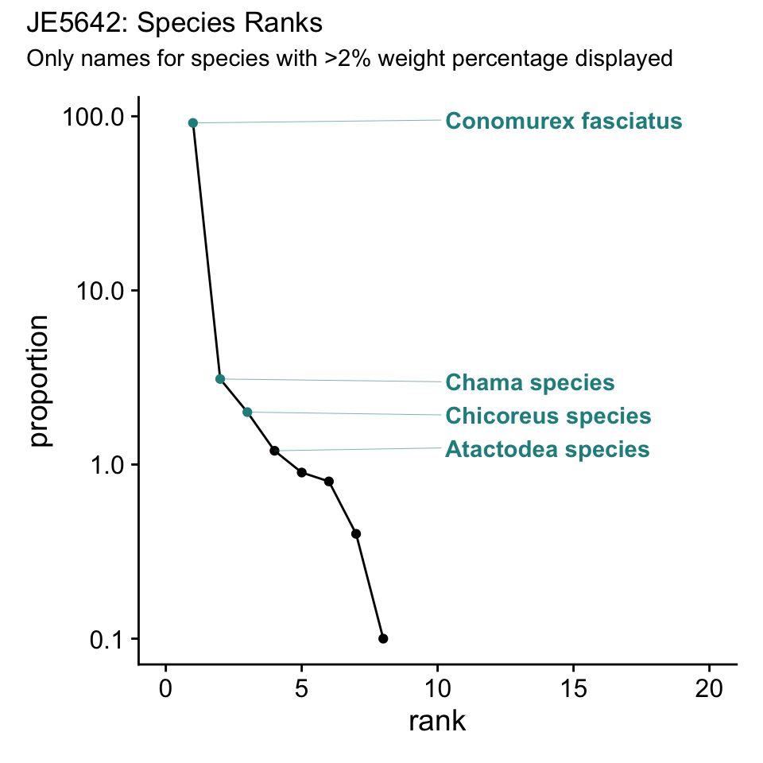

```r
for (i in 1:length(levels(Ranks$Site))) {

PLOT1 <- Ranks %>%
  filter(Site == levels(Ranks$Site)[i]) %>%
  ggplot(aes(x = rank, y = proportion, group = Site)) +
  geom_path(size = 0.5) +
  geom_point(aes(color = Dominant), show.legend = FALSE) +
  scale_color_manual(values = c(viridis_pal()(60)[30], "black")) +
  theme(legend.position = "none") +
  theme_half_open() +
  theme(strip.background = element_rect(colour = "black", fill = "white")) +
  theme(strip.text.x = element_text(face = "bold")) + scale_y_log10() +
  xlim(0, 20) +
  geom_text_repel(
    data = subset(Ranks[Ranks$Site == levels(Ranks$Site)[i], ], proportion > 1),
    aes(label = SpeciesRound, color = factor(SpeciesRound)),
    xlim = c(10, 20),
    colour = viridis_pal()(60)[30],
    direction = "y",
    hjust = 0,
    segment.size = 0.1,
    fontface = 'bold'
  )




PLOT1+plot_annotation(title= paste0(levels(Ranks$Site)[i],": Species Ranks"),subtitle = "Only names for species with >2% weight percentage displayed" )


ggsave(here(paste0("/Figures and supplementary material/Supplementary Material/3. Species ranks by site/Species_ranks_in_",levels(Ranks$Site)[i],".pdf")),height= 10, width = 10)

}
```